# Introduction

Titanic dataset contains a sample of demographic data and some information regarding 891 passengers. I have chosen Titanic data set inorder to investigate factors that made passengers more likely to survive. This data investigation will be done using Python. Although there was some sort of fate for some passengers in surviving the sinking, some groups of people were more likely to survive than others, such as women, children, and the upper-class.

```python
import pandas as pd
```

```python
import numpy as np
```

```python
import unicodecsv
```

```python
data=pd.read_csv(r'C:\Users\Barneiy\Desktop\Udacity\titanic.csv')
```

```python
len(data['PassengerId'].unique()) # checks out the total entries of the dataset
```

```
891
```

```python
data.head() # checks out few rows of the dataset
```

|  | PassengerId | Survived | Pclass | Name | Sex | Age | SibSp | Parch | Ticket | Fare | Cabin | Embarked |
| --- | --- | --- | --- | --- | --- | --- | --- | --- | --- | --- | --- | --- |
| 0 | 1 | 0 | 3 | Braund, Mr. Owen Harris | male | 22.0 | 1 | 0 | A/5 21171 | 7.2500 | NaN | S |
| 1 | 2 | 1 | 1 | Cumings, Mrs. John Bradley (Florence Briggs Th... | female | 38.0 | 1 | 0 | PC 17599 | 71.2833 | C85 | C |
| 2 | 3 | 1 | 3 | Heikkinen, Miss. Laina | female | 26.0 | 0 | 0 | STON/O2. 3101282 | 7.9250 | NaN | S |
| 3 | 4 | 1 | 1 | Futrelle, Mrs. Jacques Heath (Lily May Peel) | female | 35.0 | 1 | 0 | 113803 | 53.1000 | C123 | S |
| 4 | 5 | 0 | 3 | Allen, Mr. William Henry | male | 35.0 | 0 | 0 | 373450 | 8.0500 | NaN | S |

In order to have a general understanding of the dataset, data investigation is preferable to start with checking out the summary; the total number of entries for each variable, variable names, and data type for each variable.

```python
data.info()
```

```
<class 'pandas.core.frame.DataFrame'>
RangeIndex: 891 entries, 0 to 890
Data columns (total 12 columns):
PassengerId    891 non-null int64
Survived       891 non-null int64
Pclass         891 non-null int64
Name           891 non-null object
Sex            891 non-null object
Age            714 non-null float64
SibSp          891 non-null int64
Parch          891 non-null int64
Ticket         891 non-null object
Fare           891 non-null float64
Cabin          204 non-null object
Embarked       889 non-null object
dtypes: float64(2), int64(5), object(5)
memory usage: 83.6+ KB
```

```python
data.isnull().sum()
```

```
PassengerId      0
Survived         0
Pclass           0
Name             0
Sex              0
Age            177
SibSp            0
Parch            0
Ticket           0
Fare             0
Cabin          687
Embarked         2
dtype: int64
```

It is noticed that all variables, with the exception of 'Age', 'Cabin' and 'Embarked', have equal number of observations (891). Discovering how many variables exactly have missing values allows to identify what needs to be done to handle the problem. Based on the information given, Cabin is having 77% missing values and Age about 20%.

```python
data[['Age','Fare']].describe()
```

|  | Age | Fare |
| --- | --- | --- |
| count | 714.000000 | 891.000000 |
| mean | 29.699118 | 32.204208 |
| std | 14.526497 | 49.693429 |
| min | 0.420000 | 0.000000 |
| 25% | 20.125000 | 7.910400 |
| 50% | 28.000000 | 14.454200 |
| 75% | 38.000000 | 31.000000 |
| max | 80.000000 | 512.329200 |

Moreover, further investigation can be done to have a better understanding of some variables by exploring the basic statistics for selected variables of interest.From the result, for instance, the average age of Titanic passengers is 29.69 and their age ranges from 0.42 to 80 years of old. Moreover, the average fare was 32.20.

# Data Wrangling

Data cleaning is an important step to do before making any further analysis about the information provided in a dataset. In the Titanic dataframe, missing values of variables 'Age', 'Cabin' and 'Embarked' needs to be handled. Also recoding of some variables ('Sex', 'Age', and 'Embarked') is essential for further analysis.

### Recoding Variables

```python
data['Gender']= data['Sex'].map ({'female': 0, 'male': 1}).astype(int)
data['Embrk']= data['Embarked'].map ({'C': 1, 'Q': 2, 'S': 2})
data.head()
```

|  | PassengerId | Survived | Pclass | Name | Sex | Age | SibSp | Parch | Ticket | Fare | Cabin | Embarked | Gender | Embrk |
| --- | --- | --- | --- | --- | --- | --- | --- | --- | --- | --- | --- | --- | --- | --- |
| 0 | 1 | 0 | 3 | Braund, Mr. Owen Harris | male | 22.0 | 1 | 0 | A/5 21171 | 7.2500 | NaN | S | 1 | 2.0 |
| 1 | 2 | 1 | 1 | Cumings, Mrs. John Bradley (Florence Briggs Th... | female | 38.0 | 1 | 0 | PC 17599 | 71.2833 | C85 | C | 0 | 1.0 |
| 2 | 3 | 1 | 3 | Heikkinen, Miss. Laina | female | 26.0 | 0 | 0 | STON/O2. 3101282 | 7.9250 | NaN | S | 0 | 2.0 |
| 3 | 4 | 1 | 1 | Futrelle, Mrs. Jacques Heath (Lily May Peel) | female | 35.0 | 1 | 0 | 113803 | 53.1000 | C123 | S | 0 | 2.0 |
| 4 | 5 | 0 | 3 | Allen, Mr. William Henry | male | 35.0 | 0 | 0 | 373450 | 8.0500 | NaN | S | 1 | 2.0 |

```python
bins=[0,10,20,30,40,50,60,70,80]
group_names = ['(0,10)', '[10,20)', '[20,30)', '[30,40)' ,'[40,50)',
               '[50,60)', '[60,70)','[70,80)']
Agegroups = pd.cut(data['Age'], bins, labels=group_names)
data['Agegroups'] = pd.cut(data['Age'], bins, labels=group_names)
data['Agegroups'].dropna().head()
```

```
0    [20,30)
1    [30,40)
2    [20,30)
3    [30,40)
4    [30,40)
Name: Agegroups, dtype: category
Categories (8, object): [(0,10) < [10,20) < [20,30) < [30,40) < [40,50) < [50,60) < [60,70) < [70,80)]
```

### Missing values computation for Age

As indicated previously, 20% of the values are missing for variable Age. These missing values needs to be properly addressed as it will affect the result of any analysis or conclusion that may be drawn otherwise. Checking out the distribution of Age is a good start to see what assuptions can be drawn to fill up the missing values.

```python
%matplotlib inline
```

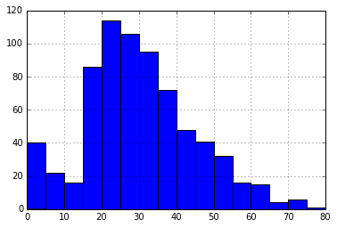

```python
data['Age'].dropna().hist(bins=16, range=(0,80))
```

The histogram reveals that the distribution of Age is somewhat Normal. The highest frequency of Age lies approximately in the age group of 20-25. From the above table also it is clear that average Age of passengers is 29.69, and median age 28.00. For passengers to be assigned on different Pclasses, age was no way a factor and nor Sex of passengers. Taking mean or median age of passengers and filling up the missing values can be an option. I would rather choose median age for computation purposes, but by taking into account the sex and Pclass of passengers. That is, I will take the median age of (Pclass 1 and Sex= Female) to replace the missing values of Age of those who are Females and who belong to Pclass 1. The process will continue for the rest of the two variables by considering the Sex and the Pclass.

```python
# Age missing values computation
median_ages = np.zeros((2,3))
median_ages
```

```
array([[ 0.,  0.,  0.],
       [ 0.,  0.,  0.]])
```

```python
data['Newage'] = data['Age']
```

```python
data[ data['Age'].isnull() ][['Gender','Pclass','Age','Newage']].head(5)
```

|  | Gender | Pclass | Age | Newage |
| --- | --- | --- | --- | --- |
| 5 | 1 | 3 | NaN | NaN |
| 17 | 1 | 2 | NaN | NaN |
| 19 | 0 | 3 | NaN | NaN |
| 26 | 1 | 3 | NaN | NaN |
| 28 | 0 | 3 | NaN | NaN |

```python
for x in range(0, 2):
    for y in range(0, 3):
        median_ages[x,y] = data[(data['Gender'] == x) & \
                              (data['Pclass'] == y+1)]['Age'].dropna().median()
```

```python
median_ages
```

```
array([[ 35. ,  28. ,  21.5],
       [ 40. ,  30. ,  25. ]])
```

```python
for x in range(0, 2):
    for y in range(0, 3):
        data.loc[ (data.Age.isnull()) & (data.Gender == x) \
                 & (data.Pclass == y+1),\
                'Newage'] = median_ages[x,y]
```

```python
data[ data['Age'].isnull() ][['Gender','Pclass','Age','Newage']].head()
```

|  | Gender | Pclass | Age | Newage |
| --- | --- | --- | --- | --- |
| 5 | 1 | 3 | NaN | 25.0 |
| 17 | 1 | 2 | NaN | 30.0 |
| 19 | 0 | 3 | NaN | 21.5 |
| 26 | 1 | 3 | NaN | 25.0 |
| 28 | 0 | 3 | NaN | 21.5 |

```python
data['Newage'].describe()
```

```
count    891.000000
mean      29.112424
std       13.304424
min        0.420000
25%       21.500000
50%       26.000000
75%       36.000000
max       80.000000
Name: Newage, dtype: float64
```

```python
data['Agemissing'] = pd.isnull(data.Age).astype(int)
```

Missing values are properly handled and kept in a new column so that the original dataset remains not disturbed. The statistics now clearly shows the new variable which is created, where the missing values are filled, shows average Age of passenger as 29.11. It is always advisable to cross check the findings by comparing the statistics of the original and the new variable.

```python
data['Age'].describe()
```

```
count    714.000000
mean      29.699118
std       14.526497
min        0.420000
25%       20.125000
50%       28.000000
75%       38.000000
max       80.000000
Name: Age, dtype: float64
```

### Missing values computation for Cabin and Embarked

```python
data['NewCabin'] = data['Cabin']
data['NewCabin']=data['Cabin'].fillna('K99')
data['NewCabin'].head()
```

```
0     K99
1     C85
2     K99
3    C123
4     K99
Name: NewCabin, dtype: object
```

```python
data['NewEmbarked'] = data['Embarked']
data['NewEmbarked']=data['Embarked'].dropna()# only two values are missing for this variable
len(data['NewEmbarked'])
```

```
891
```

# Factors Affecting Survival

I have the impression that rate of survival might have been affected by the socio economic status of passengers, that is, those who were in the first class might have got the greatest chance of survival compared to the other classes. Those who were in the highest class might have received a great care, or given life jackets compared to others. Moreover, I assume priority might have been given to children and women.

Since my interest is to find out What factors made people more likely to survive, I would like to explore the frequency table of survived passengers (taking Survived as a dependent variable) against passengers gender, their class and Age (three independent variables). For the analysis, I will also consider all the three independent variables as categorical variables (Sex, Pclass and Age goups will be taken).

To test if there is association or some sort of relation between these variables, I will consider contigency table, Conditional Percents (row percents and columns percents). By conditional percents I mean, my conclusions will be based on the following idea.

Two categorical variables are related (associated) if at least two rows noticeably differ in the pattern of row percents, and if at least two columns noticeably differ in the pattern of columns percents.

Inorder to test the significance of the contingency tables, test statistic Chi-square will be taken.

## Test 1. Association between Survived and Passengers' class

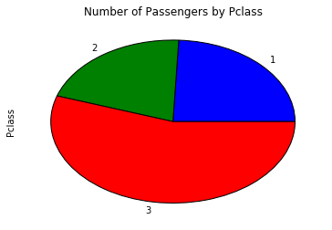

```python
data['Pclass'].value_counts(sort=False).plot(kind='pie',title='Number of Passengers by Pclass')
```

From the pie chart, we learned that majority of the passengers (55.1%) were in the third class, followed by 24.2% from first class and 20.6% in the second class.

```python
New_Survived = pd.Categorical(data["Survived"])
New_Survived = New_Survived.rename_categories(["Died","Survived"])
New_Survived.describe()# count and proportion of survived
```

| categories | counts | freqs |
| --- | --- | --- |
| Died | 549 | 0.616162 |
| Survived | 342 | 0.383838 |

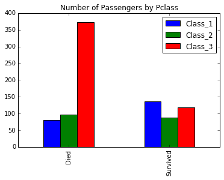

```python
survived_by_Pclass = pd.crosstab(index=data['Survived'],
                             columns=[data['Pclass']])

survived_by_Pclass.columns=['Class_1','Class_2','Class_3']
survived_by_Pclass.index= ['Died','Survived']

survived_by_Pclass.plot(kind='bar',title='Number of Passengers by Pclass')
```

The above bar graph shows the total number of passengers died and survived in each passengers class. I will consider only those passengers who survived for my analysis.

```python
import seaborn as sns
```

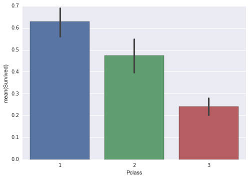

```python
sns.barplot(x='Pclass', y='Survived', data=data)
```

The row percent also shows 39.7% passengers who have survived belong to the 1st class, 34.8% to the 3rd class and 25.4% to the 2nd class.

```python
survived_by_Pclass = pd.crosstab(index=data["Survived"],
                             columns=data["Pclass"])
survived_by_Pclass
Pclass_rotio= survived_by_Pclass.div(survived_by_Pclass.sum())
Survived_by_Pclass_column_percent= Pclass_rotio * 100
Survived_by_Pclass_column_percent.round(2)
```

| Pclass Survived | 1 | 2 | 3 |
| --- | --- | --- | --- |
| 0 | 37.04 | 52.72 | 75.76 |
| 1 | 62.96 | 47.28 | 24.24 |

```python
Survived_by_Pclass = pd.crosstab(index=data['Survived'],
                         columns=data['Pclass'])

survived_by_Pclass.columns=['Class_1','Class_2','Class_3']
survived_by_Pclass.index= ['Died','Survived']

row_rotio= Survived_by_Pclass.div(Survived_by_Pclass.sum(axis='columns'),axis='index')
Survived_by_Pclass_row_percent= row_rotio * 100
Survived_by_Pclass_row_percent.round(2) # Pclass survived compared to over all survivors
```

| Pclass Survived | 1 | 2 | 3 |
| --- | --- | --- | --- |
| 0 | 14.57 | 17.67 | 67.76 |
| 1 | 39.77 | 25.44 | 34.80 |

Taking in to consideration conditional percents, the row and column percents, it is noted that there is noticeable difference between the row percent and column percent of passengers Pclass. This shows that there is some association or relation between Survival and Pclass. We can conclude that the survival is not due to random variation. Before I proceed with the Chi-square test, I would like to further investigate what survival looks like with in the the classes. I will consider passengers Sex and Age with in the three classes.

```python
survived_by_sex_and_Pclass = pd.crosstab(index=data["Survived"],
                             columns=[data["Pclass"],
                                      data["Sex"]],
                             margins=True)

columns_ratio = survived_by_sex_and_Pclass/survived_by_sex_and_Pclass.ix['All']
percent_survived_by_sex_and_Pclass = columns_ratio * 100
percent_survived_by_sex_and_Pclass.round(2)
```

| Pclass Sex Survived | 1 female | 1 male | 2 female | 2 male | 3 female | 3 male | All |
| --- | --- | --- | --- | --- | --- | --- | --- |
| 0 | 3.19 | 63.11 | 7.89 | 84.26 | 50.0 | 86.46 | 61.62 |
| 1 | 96.81 | 36.89 | 92.11 | 15.74 | 50.0 | 13.54 | 38.38 |
| All | 100.00 | 100.00 | 100.00 | 100.00 | 100.0 | 100.00 | 100.00 |

With in the three different classes, majority of the survivors were Females. That is, out of the total number of females who were in the first class, 96.8% survived. Likewise in the second class 92.1% and in the third class 50% of females survived.

Chi-square test

Test Hypothesis: I will conduct chi-square test to determine the relationship between variables 'Survived' and 'Passengers Class'.

HO: there is no association between Survived and Passengers class (population mean of Survived is same as population mean of Pclass)  
H1: there is association between Survived and Passengers class (there is difference in the population mean of Survived and Pclass)

```python
from scipy.stats import chi2_contingency
chi2_contingency(pd.crosstab(data.Survived, data.Pclass))
```

```
(102.88898875696056,
 4.5492517112987927e-23,
 2L,
 array([[ 133.09090909,  113.37373737,  302.53535354],
        [  82.90909091,   70.62626263,  188.46464646]]))
```

the output shows the p-value 4.549e-23, which is less than 0.05, therefore at 95% confidence level Ho is rejected and it is concluded that survival is not distributed similarly across the different Passengers Class.

## Test 2. Association between Survived and Sex

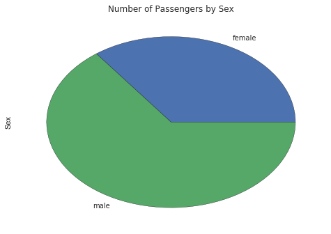

```python
data['Sex'].value_counts(sort=False).plot(kind='pie',title='Number of Passengers by Sex')
```

The pie chart shows,out of the 891 Titanic passengers, 64.7% were male and 35.2% female.

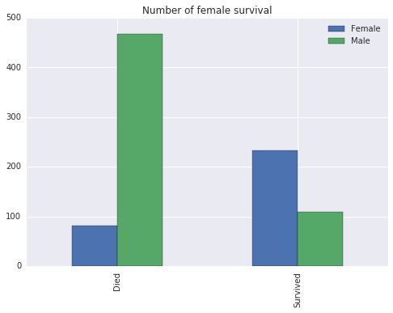

```python
survived_by_Sex = pd.crosstab(index=data['Survived'],
                             columns=[data['Sex']])

survived_by_Sex.columns=['Female','Male']
survived_by_Sex.index= ['Died','Survived']

survived_by_Sex.plot(kind='bar', title='Number of female survival')
```

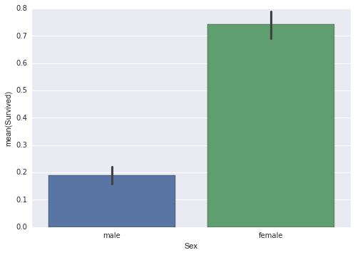

```python
sns.barplot(x='Sex', y='Survived', data=data)
```

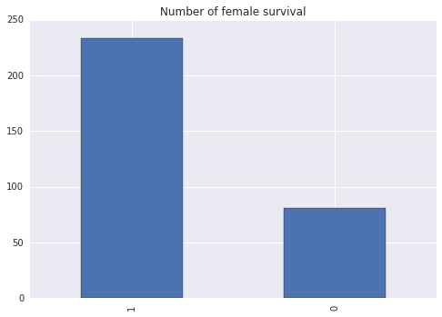

```python
data[data.Sex=='female'].Survived.value_counts().plot(kind='bar',title='Number of female survival')
```

```python
survived_by_Sex = pd.crosstab(index=data["Survived"],
                             columns=data["Sex"])

survived_by_Sex.columns=['Female','Male']
survived_by_Sex.index= ['Died','Survived']

Sex_rotio= survived_by_Sex.div(survived_by_Sex.sum())
Survived_by_Sex_column_percent= Sex_rotio * 100
Survived_by_Sex_column_percent.round(2) # female/male survived compared to total number of female/male
```

|  | Female | Male |
| --- | --- | --- |
| Died | 25.8 | 81.11 |
| Survived | 74.2 | 18.89 |

```python
survived_by_Sex = pd.crosstab(index=data['Survived'],
                         columns=data['Sex'])

survived_by_Sex.columns=['Female','Male']
survived_by_Sex.index= ['Died','Survived']

Sex_rotio= survived_by_Sex.div(survived_by_Sex.sum(axis='columns'),axis='index')
Survived_by_Sex_row_percent= Sex_rotio * 100
Survived_by_Sex_row_percent.round(2) #  female/male survived compared to over all survivors
```

|  | Female | Male |
| --- | --- | --- |
| Died | 14.75 | 85.25 |
| Survived | 68.13 | 31.87 |

If we take a look at the conditional percents, the row and column percents, it is noted that there is noticeable difference between the row percent and column percent of passengers Sex. This shows that there is some relation between Survival and Sex. We can say that the survival is not due to random variation.

Chi-square test

Test Hypothesis: Chi-square test to determine the relationship between variables 'Survived' and 'Passengers Sex'.

HO: there is no association between Survived and Passengers sex (population mean of Survived is same as population mean of sex)  
H1: there is association between Survived and Passengers sex (there is difference in the population mean of Survived and sex)

```python
from scipy.stats import chi2_contingency
chi2_contingency(pd.crosstab(data.Survived, data.Sex))
```

```
(260.71702016732104,
 1.1973570627755645e-58,
 1L,
 array([[ 193.47474747,  355.52525253],
        [ 120.52525253,  221.47474747]]))
```

the Chi-square output shows the p-value 1.1973e-58, which is less than 0.05, therefore at 95% confidence level Ho is rejected and it is concluded that Survival was not similarly distributed accross Passengers Sex.

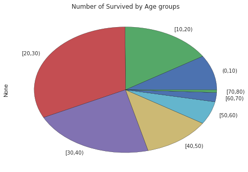

```python
data['Agegroups'].dropna().value_counts(sort=False).plot(kind='pie', title='Number of Survived by Age groups')
```

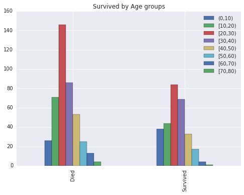

```python
survived_by_Age = pd.crosstab(index=data['Survived'],
                             columns=[data['Agegroups'].dropna()])

survived_by_Age.columns=['(0,10)','[10,20)','[20,30)','[30,40)','[40,50)','[50,60)','[60,70)','[70,80)']
survived_by_Age.index= ['Died','Survived',]

survived_by_Age.plot(kind='bar',title='Survived by Age groups')
```

The above bar graph shows the total number of passengers survived and died per each category (Age groups). Since i am interested in the percentage of passengers survived in each age group, I will disregard those who died.

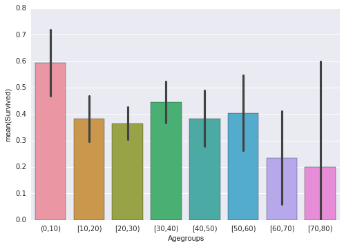

```python
sns.barplot(x='Agegroups', y='Survived', data=data)
```

Percentage of Survived passengers with in each Age group

Percentage of Survived passengers as compared to over all survival(see row percent table below)

13.1% passengers who have survived belong to age group (0 to 10), 15.1% belong to age group (10 to 20), 28.9% belong to age group (20 to 30), 23.7% belong to age group (30 to 40), 11.3% belong to (40 to 50) and 5.8% belong to age group (50 to 60).

```python
survived_by_Age = pd.crosstab(index=data['Survived'],
                             columns=[data['Agegroups'].dropna()],
                             margins=True)

survived_by_Age.columns=['(0,10)','[10,20)','[20,30)',\
                         '[30,40)','[40,50)','[50,60)',\
                         '[60,70)','[70,80)','Total']
survived_by_Age.index= ['Died','Survived','Total']

Age_ratio = survived_by_Age/survived_by_Age.ix['Total']
percent_survived_by_Age = Age_ratio * 100
percent_survived_by_Age.round(2)
```

|  | (0,10) | [10,20) | [20,30) | [30,40) | [40,50) | [50,60) | [60,70) | [70,80) | Total |
| --- | --- | --- | --- | --- | --- | --- | --- | --- | --- |
| Died | 40.62 | 61.74 | 63.48 | 55.48 | 61.63 | 59.52 | 76.47 | 80.0 | 61.62 |
| Survived | 59.38 | 38.26 | 36.52 | 44.52 | 38.37 | 40.48 | 23.53 | 20.0 | 38.38 |
| Total | 100.00 | 100.00 | 100.00 | 100.00 | 100.00 | 100.00 | 100.00 | 100.0 | 100.00 |

```python
survived_by_Age = pd.crosstab(index=data['Survived'],
                             columns=[data['Agegroups'].dropna()])

Age_rotio= survived_by_Age.div(survived_by_Age.sum(axis='columns'),axis='index')
Survived_by_Age_row_percent= Age_rotio * 100
Survived_by_Age_row_percent.round(2)
```

| Agegroups Survived | (0,10) | [10,20) | [20,30) | [30,40) | [40,50) | [50,60) | [60,70) | [70,80) |
| --- | --- | --- | --- | --- | --- | --- | --- | --- |
| 0 | 6.132075 | 16.745283 | 34.433962 | 20.283019 | 12.50000 | 5.896226 | 3.066038 | 0.943396 |
| 1 | 13.103448 | 15.172414 | 28.965517 | 23.793103 | 11.37931 | 5.862069 | 1.379310 | 0.344828 |

Considering conditional percents, the row and column percents, there is noticeable difference between the row percent and column percent of passengers Age groups. This shows that there is some association between Survival and Age groups. We can conclude that the survival is not due to random variation.

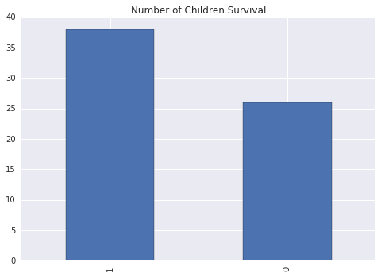

```python
data[data.Agegroups =='(0,10)'].Survived.value_counts().plot(kind='bar',title='Number of Children Survival')
```

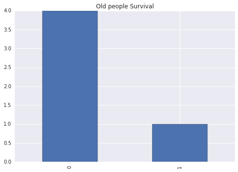

```python
data[data.Agegroups=='[70,80)'].Survived.value_counts().plot(kind='bar',title='Old people Survival')
```

Although, the percentage of survived Children (aged between 0 & 10) reaveals that it is the highest percentage (59.3%) compared to other age groups, the percentage of survived Old people is low (20.0%). From this we can conclude that Children were given priority.

```python
from scipy.stats import chi2_contingency
chi2_contingency(pd.crosstab(data.Survived, data.Agegroups.dropna()))
```

```
(15.296687749545693,
 0.03237887956708356,
 7L,
 array([[  38.00560224,   68.29131653,  136.58263305,   92.04481793,
           51.07002801,   24.94117647,   10.0952381 ,    2.96918768],
        [  25.99439776,   46.70868347,   93.41736695,   62.95518207,
           34.92997199,   17.05882353,    6.9047619 ,    2.03081232]]))
```

the Chi-square output shows the p-value 0.0323 which is less than 0.05, therefore at 95% confidence level Ho is rejected and it is concluded that Survival was not similarly distributed among Age groups.

# Conclusions

Using contingency table (chi-square test), it is proved that there is association between Survived and the three factors (Pclass, Gender and Age). However, this doesn't imply that we should ignore other factors that might have an impact either between or with in the different variables. It should also be noted that chi-square test does not give us much information about the strength of the relationship of the variables or its substantive significance in the population. For example, I discovered that survival is not distributed similarly across the different Classes of passengers. Based on the results we can't measure the strength of the relationship between the three different classes.For that matter chi-square together with measures of association like lambda, Cramer's V or gamma needs to be done to guide us in deciding whether a relationship is important and worth pursuing.

The titanic dataset is quite interesting subject for me. I would like to investigate more to know if there is significant difference between groups (ANOVA) for the continous variables (age and fare). I would also be interested to do further analysis of the variables (Parch and SibSp) to learn indetail if there is association and it might be related to chances of survival.

Reference:http://pandas.pydata.org/ https://onlinecourses.science.psu.edu/stat200/node/71 https://plot.ly/python/bar-charts/#stacked-bar-chart http://stackoverflow.com/questions https://en.wikipedia.org/wiki/Pearson%27s_chi-squared_test#Assumptions